# Udacity Project I - Investigating a dataset

#### DataSet used : No-show appointments

(original source on Kaggle)

## Brief Introduction

The dataset used for our case study was loaded into our notebook as well as the packages which will be used to carry out our analysis. For this analysis, suitable packages are Pandas, Numpy and Matplotlib. After having a quick overview of the dataset, the following tentative questions arose which i assumed could be important to answer or start off with as we investigate the dataset.

### Insightful Questions.

1- Could benefiting from a scholarship impact a patient's response to his/her appoinment? i.e Did patients who benefited from a scholarship show up more than those who didn't ?

2- Did the proportion of patients who received an SMS reminder honour their appointments more than the proportion who didn't?

3- What factors are important for us to know in order to predict if a patient will show up for their scheduled appointment?

```python
#loading our dataset

import pandas as pd
import numpy as np
import seaborn as sn
import matplotlib.pyplot as plt
%matplotlib inline

df = pd.read_csv('noshowappointments-kagglev2-may-2016.csv')
df.head(1)
```

|  | PatientId | AppointmentID | Gender | ScheduledDay | AppointmentDay | Age | Neighbourhood | Scholarship | Hipertension | Diabetes | Alcoholism | Handcap | SMS_received | No-show |
| --- | --- | --- | --- | --- | --- | --- | --- | --- | --- | --- | --- | --- | --- | --- |
| 0 | 2.987250e+13 | 5642903 | F | 2016-04-29T18:38:08Z | 2016-04-29T00:00:00Z | 62 | JARDIM DA PENHA | 0 | 1 | 0 | 0 | 0 | 0 | No |

## Data Cleaning Phase

In this phase, we searched for incorrect data types, null/missing values, duplicates, erronous data and even grammatical errors. This procedure led to some columns being renamed/modified to better enhance data comprehension.

```python
#Checking for duplicates, null values and incorrect datatypes
sum(df.duplicated())
```

```
0
```

```python
df.info()
```

```
<class 'pandas.core.frame.DataFrame'>
RangeIndex: 110527 entries, 0 to 110526
Data columns (total 14 columns):
 #   Column          Non-Null Count   Dtype
---  ------          --------------   -----
 0   PatientId       110527 non-null  float64
 1   AppointmentID   110527 non-null  int64
 2   Gender          110527 non-null  object
 3   ScheduledDay    110527 non-null  object
 4   AppointmentDay  110527 non-null  object
 5   Age             110527 non-null  int64
 6   Neighbourhood   110527 non-null  object
 7   Scholarship     110527 non-null  int64
 8   Hipertension    110527 non-null  int64
 9   Diabetes        110527 non-null  int64
 10  Alcoholism      110527 non-null  int64
 11  Handcap         110527 non-null  int64
 12  SMS_received    110527 non-null  int64
 13  No-show         110527 non-null  object
dtypes: float64(1), int64(8), object(5)
memory usage: 11.8+ MB
```

```python
df.describe()
```

|  | PatientId | AppointmentID | Age | Scholarship | Hipertension | Diabetes | Alcoholism | Handcap | SMS_received |
| --- | --- | --- | --- | --- | --- | --- | --- | --- | --- |
| count | 1.105270e+05 | 1.105270e+05 | 110527.000000 | 110527.000000 | 110527.000000 | 110527.000000 | 110527.000000 | 110527.000000 | 110527.000000 |
| mean | 1.474963e+14 | 5.675305e+06 | 37.088874 | 0.098266 | 0.197246 | 0.071865 | 0.030400 | 0.022248 | 0.321026 |
| std | 2.560949e+14 | 7.129575e+04 | 23.110205 | 0.297675 | 0.397921 | 0.258265 | 0.171686 | 0.161543 | 0.466873 |
| min | 3.921784e+04 | 5.030230e+06 | -1.000000 | 0.000000 | 0.000000 | 0.000000 | 0.000000 | 0.000000 | 0.000000 |
| 25% | 4.172614e+12 | 5.640286e+06 | 18.000000 | 0.000000 | 0.000000 | 0.000000 | 0.000000 | 0.000000 | 0.000000 |
| 50% | 3.173184e+13 | 5.680573e+06 | 37.000000 | 0.000000 | 0.000000 | 0.000000 | 0.000000 | 0.000000 | 0.000000 |
| 75% | 9.439172e+13 | 5.725524e+06 | 55.000000 | 0.000000 | 0.000000 | 0.000000 | 0.000000 | 0.000000 | 1.000000 |
| max | 9.999816e+14 | 5.790484e+06 | 115.000000 | 1.000000 | 1.000000 | 1.000000 | 1.000000 | 4.000000 | 1.000000 |

After checking for duplicates, null values and incorrect data type, it was discovered none of these anomalies were present but nonetheless an erreonous value was found. Using the code df.describe(), we could observe some incoherence on the Statistics of the Age column. On the column age, we can observe a minimum value of -1, which must be an error as someone's age cannot be -1. We proceeded to then crosscheck any other value which could as well have an error of this nature for the Age column only given the other columns were judged to have coherent and consistent entries.

```python
#on the column age, we can observe a minimum value of -1, which must be an error as someone's age cannot be -1
#let us search for how many entries could have this error
error = df.query('Age <0')
error.count()['Age']
```

[output not shown]

```python
#Upon searching we observe we have just one entry as such. we proceed to then replace that negative entry to a positive one
#assuming this could have been a typing error
df['Age']=df['Age'].replace(-1,1)

#running the code on the previous cell confirms our operation was successful
```

We proceed to rename some columns to facilitate our analysis, and we conclude the cleaning phase.

```python
#renaming some columns to adjust their spellings
df.rename(columns={"No-show":"No_show","Handcap":"Handicap","Hipertension":"Hypertension"}, inplace=True)
df.head(1)
```

|  | PatientId | AppointmentID | Gender | ScheduledDay | AppointmentDay | Age | Neighbourhood | Scholarship | Hypertension | Diabetes | Alcoholism | Handicap | SMS_received | No_show |
| --- | --- | --- | --- | --- | --- | --- | --- | --- | --- | --- | --- | --- | --- | --- |
| 0 | 2.987250e+13 | 5642903 | F | 2016-04-29T18:38:08Z | 2016-04-29T00:00:00Z | 62 | JARDIM DA PENHA | 0 | 1 | 0 | 0 | 0 | 0 | No |

### Some Statistics about our data

```
Hypertension    21801
Diabetes         7943
Alcoholism       3360
Handicap         2042
dtype: int64
```

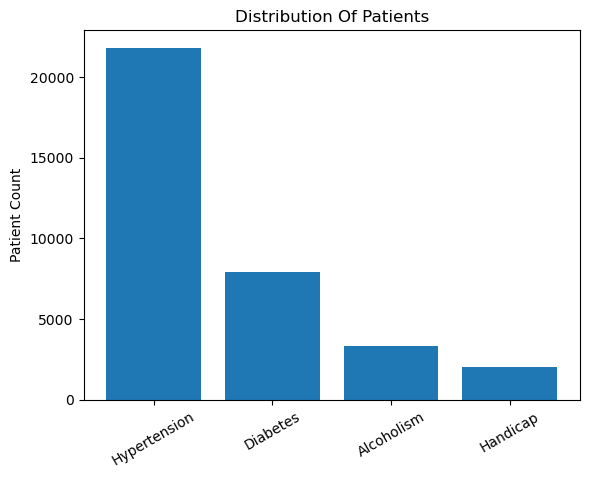

```python
#In order to get a broad view on our data, the following statistics were made:
#first we create a list of patient types
P_types = ['Hypertension','Diabetes','Alcoholism','Handicap']

#then we have an overview of the count of patients per illness type

x1 = df.query('Hypertension == 1')['Hypertension'].count()
y1 = df.query('Diabetes == 1')['Diabetes'].count()
z1 = df.query('Alcoholism == 1')['Alcoholism'].count()
a1 = df.query('Handicap == 1')['Handicap'].count()


#storing them in a list
counts = [x1,y1,z1,a1]
data = pd.Series(counts,index=P_types)


#creating a function to display our data together:

def illness(P_types,counts,data):
    plt.bar(P_types,counts)
    plt.title('Distribution Of Patients')
    plt.ylabel('Patient Count')
    plt.xticks(rotation = 30, horizontalalignment = "center")
    return data


illness(P_types,counts,data)
```

From the bar Chart above, we can observe that we have more patients suffering from hypertension than any other illness and less from a handicap than any other illness

```
infants             7431
kids               13606
adolescents         6343
young adults       18252
middle-aged        23475
Old-aged adults    42941
dtype: int64
```

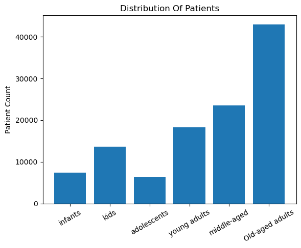

```python
#We can also view the count of different patients' age, according to categoryi.e
# 0 - 2  for infants
# 3 - 12 for kids
# 13 - 17 for adolescents
# 18 - 30 young adults
# 30 - 45 middle aged adults
#above 45 for Old adults

#let's create a list storing these categories
age_groups = ['infants','kids','adolescents','young adults','middle-aged', 'Old-aged adults']

b = df.query('0 <= Age <= 2')['Age'].count()
c = df.query('3 <= Age <= 12')['Age'].count()
d = df.query('13 <= Age <= 17')['Age'].count()
e = df.query('18 <= Age <= 30')['Age'].count()
f = df.query('30 <= Age <= 45')['Age'].count()
g = df.query('46 <= Age')['Age'].count()

count_two = [b,c,d,e,f,g]
data2 = pd.Series(count_two,index=age_groups)




illness(age_groups,count_two,data2)
```

| Gender | PatientId |
| --- | --- |
| F | 71840 |
| M | 38687 |

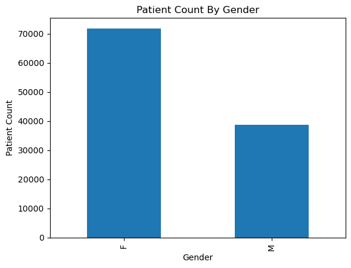

```python
#Lastly we have a display of the patients' gender

df.groupby('Gender')['PatientId'].count().plot(kind = 'bar')
plt.title('Patient Count By Gender')
plt.ylabel('Patient Count')
df.groupby('Gender')[['PatientId']].count()
```

we can deduce from here that most of the patients are female rather than male as they have a greater count.

## Exploratory Phase

### Do patients who receive sms show up for their appointments?

```python
df.SMS_received.unique()
```

```
array([0, 1], dtype=int64)
```

```python
df.SMS_received.value_counts()
```

```
0    75045
1    35482
Name: SMS_received, dtype: int64
```

```python
df.No_show.value_counts()
```

```
No     88208
Yes    22319
Name: No_show, dtype: int64
```

```python
Got_sms=df.query('SMS_received==1').query('Scholarship==0')
Showed_Up= Got_sms[Got_sms['No_show']=='No'].count()['No_show']
Not_Show=Got_sms[Got_sms['No_show']=='Yes'].count()['No_show']
print(Not_Show,
Showed_Up)
```

```
8600 23377
```

```
(-1.1190032341863618,
 1.1110753624670784,
 -1.115863872916446,
 1.1007554225198308)
```

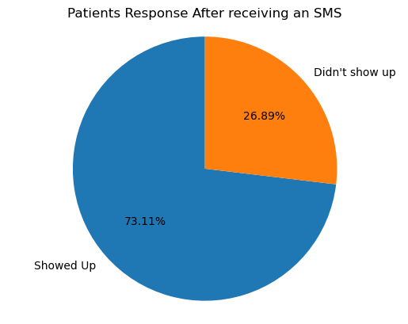

```python
labels=['Showed Up',"Didn't show up"]
plt.title("Patients Response After receiving an SMS")
plt.pie([Showed_Up,Not_Show],labels = labels, startangle=90, autopct='%.2f%%')
plt.axis('equal')
```

Here,It can be observed that a greater percentage of patients(73.11%) showed up for their appoinments after receiving a text message

### What proportion of patients with a scholarship show up for their appoinments?

```python
#first, we get the number of patients on a scholarship ONLY
schol = df.query('Scholarship==1').query('SMS_received==0')
schol_count = schol.count()['No_show']
schol_count
```

```
7356
```

```python
#then we find the proportion of patients in this set that showed up for their appoinments
schol_show = schol[schol['No_show']=='No']
schol_show_count=schol_show.count()['No_show']
schol_show_count
```

```
5962
```

```python
no_show = schol_count - schol_show_count
no_show
```

```
1394
```

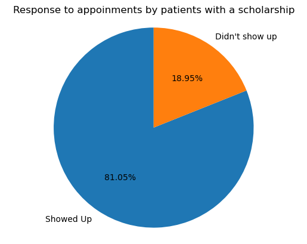

```python
#displaying the various proportions
labels=['Showed Up',"Didn't show up"]
plt.pie([schol_show_count,no_show],labels = labels, startangle=90, autopct='%.2f%%')
plt.axis('equal')
plt.title("Response to appoinments by patients with a scholarship")
```

Here,It can be observed that a greater percentage of patients(81.05%) who possess a scholarship, showed up for their appoinments as compared to those who didn't.

### What proportion of patients show up for their appointment after receiving an sms and a scholarship?

```python
#first we get the number of patients on a scholarship who received an sms
schol_sms_all = df.query('Scholarship==1').query('SMS_received==1')
schol_sms_all_count = schol_sms_all.count()['No_show']
schol_sms_all_count
#then we get those who showed up
schol_sms_show_all = schol_sms_all.query('No_show=="No"').count()['No_show']
no_show_all = schol_sms_all_count - schol_sms_show_all
no_show_all
```

```
1184
```

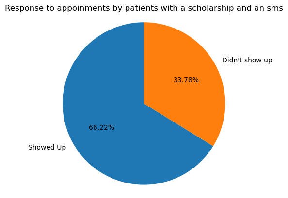

```python
plt.pie([schol_sms_show_all,no_show_all],labels = labels, startangle=90, autopct='%.2f%%')
plt.axis('equal')
plt.title("Response to appoinments by patients with a scholarship and an sms")
```

Considering both SMS and scholarships as factors for showing up for an appoinment, 66.22% of those benefiting from these two factors showed up for their appoinment. Where as a lesser proportion(33.78%) did not show up despite receiving an sms and possessing a scholarship.

#### Certainly, some people showed up even though they didn't receive any thing. How many are they?

```python
#let us get the count of patients who did't receive an sms nor scholarship but stilled showed up
none_show_count = df.query('Scholarship==0').query('SMS_received==0').query('No_show=="No"').count()['No_show']
none_show_count
```

```
56548
```

```
([0, 1, 2, 3],
 [Text(0, 0, ''), Text(0, 0, ''), Text(0, 0, ''), Text(0, 0, '')])
```

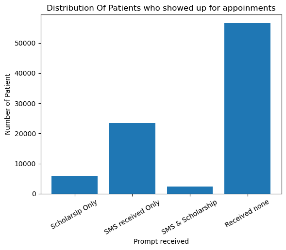

```python
#Now let us plot the different category of patients who showed up for their appoinment
plt.bar(['Scholarsip Only','SMS received Only','SMS & Scholarship','Received none'],
        [schol_show_count,Showed_Up,schol_sms_show_all,none_show_count])
plt.title("Distribution Of Patients who showed up for appoinments")
plt.ylabel('Number of Patient')
plt.xlabel('Prompt received')
plt.xticks(rotation = 30, horizontalalignment = "center")
```

From our above chart, we can observe that those who showed up the most where patients who didn't benefit from neither a scholarship nor an sms

### What about those who did not show up? Did they get an sms to remind them and/or a scholarship to support them?

```python
#Now let us get the count of those who didn't receive a scholarship nor sms and didn't show up for their appointments
no_show_none = df.query('Scholarship==0').query('SMS_received==0').query('No_show=="Yes"').count()['No_show']
#Now let us get the count of those who didn't receive a scholarship but received an sms and didn't show up for their appointments
no_show_sms = df.query('Scholarship==0').query('SMS_received==1').query('No_show=="Yes"').count()['No_show']
#Now let us get the count of those who received a scholarship, but not and sms and didn't show up for their appointments
no_show_schol = df.query('Scholarship==1').query('SMS_received==0').query('No_show=="Yes"').count()['No_show']
#Now let us get the count of those who received a scholarship and sms but didn't show up for their appointments
no_show_all = df.query('Scholarship==1').query('SMS_received==1').query('No_show=="Yes"').count()['No_show']
```

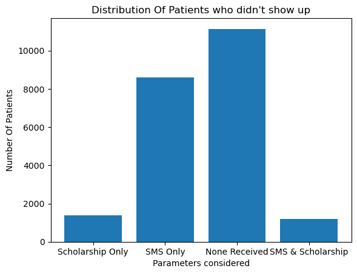

```python
#Now let us plot the data above with a bar chart
plt.bar(['Scholarship Only','SMS Only','None Received','SMS & Scholarship'],[no_show_schol,no_show_sms,no_show_none,no_show_all])
plt.title("Distribution Of Patients who didn't show up")
plt.xlabel("Parameters considered")
plt.ylabel('Number Of Patients')
```

From the chart above, we can also deduce that the greatest proportion of patients who didn't show up for their appoinment were those who didn't receive neither an sms nor a scholarship. It is important to note as well, that this number(11141) is inferior to the number of patients who didn't benefit from neither a scholarship nor an sms but still showed up for their appoinments(56548).

### Question : What proprotion of patient with different types of illness show up for appoinment?

```python
#Recall we created a list of patient types under the statistics section

#we create an array with the help of a for loop that will store:
#A) - the count for each disease
P_numbers = []

#B) - the count of patients that show up for appoinments, for each disease type
P_show_up = []

#C) - the count of patients that have a scholarship ONLY, for each disease type
P_schol = []

#D) - the count of patients that received an sms ONLY and show up for appointments, for each disease type
P_sms_show_up = []

#E) - the count of patients that show up for appoinments and have a scholarship ONLY, for each disease type
P_schol_show_up = []

#F) - the count of patients that show up for appoinments that have a scholarship and received an sms, for each disease type
P_schol_sms = []
P_schol_sms_show_up = []


for p in P_types:
    illness = df[df[p]==1]
    ill_count = illness.count()[p]
    P_numbers.append(ill_count)
    print("Type of illness :",p)
    print("Number of Patients :",ill_count)

#what proportion of patients with each disease show up for appointments?
    ill_showup = illness.query('No_show=="No"')
    ill_show_count = ill_showup.count()[p]
    P_show_up.append(ill_show_count)
    print("Number of Patients who showed up for appoinments :",ill_show_count)

#what proportion of patients with each disease show up for appointments after receiving an sms ONLY
    ill_show_sms = ill_showup.query('SMS_received==1').query('Scholarship==0')
    ill_show_sms_count = ill_show_sms.count()[p]
    P_sms_show_up.append(ill_show_sms_count)
    print("Number of Patients who showed up after receiving an sms only:",ill_show_sms_count)


#what proportion of patients with each disease benefit from a scholarship without receiving an sms
    ill_schol = illness.query('Scholarship == 1').query('SMS_received==0')
    ill_schol_count = ill_schol.count()[p]
    P_schol.append(ill_schol_count)
    print("Number of patients having a scholarship: ",ill_schol_count)

    #what proportion now show up for appoinments
    ill_schol_show = ill_schol.query('No_show=="No"')
    ill_schol_show_count = ill_schol_show.count()[p]
    P_schol_show_up.append(ill_schol_show_count)
    print("Number of patients having a scholarship only and who showed up :",ill_schol_show_count)

#Now what proportion of patients benefit from a scholarship and receive sms
    schol_sms = illness.query('Scholarship == 1').query('SMS_received==1')
    schol_sms_count = schol_sms.count()[p]
    P_schol_sms.append(schol_sms_count)
    print("Number of patients having a scholarship and an sms:",schol_sms_count)

    #what proportion now show up for appointments
    schol_sms_showup = schol_sms.query('No_show == "No"')
    schol_sms_showup_count = schol_sms_showup.count()[p]
    P_schol_sms_show_up.append(schol_sms_showup_count)
    print("Number of patients having a scholarship and an sms who showed up :",schol_sms_showup_count)

P_numbers
P_show_up
```

```
Type of illness : Hypertension
Number of Patients : 21801
Number of Patients who showed up for appoinments : 18029
Number of Patients who showed up after receiving an sms only: 4907
Number of patients having a scholarship:  1310
Number of patients having a scholarship only and who showed up : 1094
Number of patients having a scholarship and an sms: 574
Number of patients having a scholarship and an sms who showed up : 418
Type of illness : Diabetes
Number of Patients : 7943
Number of Patients who showed up for appoinments : 6513
Number of Patients who showed up after receiving an sms only: 1687
Number of patients having a scholarship:  392
Number of patients having a scholarship only and who showed up : 321
Number of patients having a scholarship and an sms: 177
Number of patients having a scholarship and an sms who showed up : 125
Type of illness : Alcoholism
Number of Patients : 3360
Number of Patients who showed up for appoinments : 2683
Number of Patients who showed up after receiving an sms only: 506
Number of patients having a scholarship:  403
Number of patients having a scholarship only and who showed up : 315
Number of patients having a scholarship and an sms: 125
Number of patients having a scholarship and an sms who showed up : 64
Type of illness : Handicap
Number of Patients : 2042
Number of Patients who showed up for appoinments : 1676
Number of Patients who showed up after receiving an sms only: 338
Number of patients having a scholarship:  122
Number of patients having a scholarship only and who showed up : 108
Number of patients having a scholarship and an sms: 38
Number of patients having a scholarship and an sms who showed up : 25
```

```
[18029, 6513, 2683, 1676]
```

[figure not shown]

```python
#Plotting our computed data on patients
data = [P_numbers,P_show_up,P_schol,P_sms_show_up,P_schol_show_up,P_schol_sms,P_schol_sms_show_up]
X = np.arange(4)
plt.figure(figsize=(10,8))
#ax = fig.add_axes([0,0,1,1])
plt.bar(X + 0.00, data[0], color = 'red', width = 0.15)
plt.bar(X + 0.15, data[1], color = 'green', width = 0.15)
plt.bar(X + 0.30, data[2], color = 'blue', width = 0.15)
plt.bar(X + 0.45, data[3], color = 'yellow', width = 0.15)
plt.bar(X + 0.60, data[4], color = 'pink', width = 0.15)
plt.bar(X + 0.75, data[5], color = 'orange', width = 0.15)
plt.bar(X + 0.80, data[6], color = 'violet', width = 0.15)
plt.xticks(X,P_types)
plt.ylabel("Patient Count")
plt.title("Distribution Of Patients grouped by Illness")
plt.legend(["Number Of Patients","Total Patients who showed up","showed up after receiving an sms only","having a scholarship only"
           ,"having a scholarship only and who showed up","having a scholarship and an sms","having a scholarship and an sms who showed up"])
```

With the help of our chart above, we can get an overview of the different patients categorised by illness and response to their appoinment, as well as the benefits possessed.

## Conclusion

Using exploratory analysis. a tentative conclusion we can give is, though receiving an sms and getting a scholarship could be factors that influence a patient showing up for their appointment, patients who have a scholarship are more likely to show up for appointments that patients who only receive an sms for a reminder.

### Limitations

- Lack of information on patients(More relevant variables) to properly analyse other possible factors affecting dependent variables.
- Little knowledge and expertise in writing scientific papers on the field from which our data is derived.
- Little Knowledge about the data collection methods used for collecting these data and in what conditions they were collected.